# Modelado predictivo

2023-04-9

Víctor Guirado Osorio

- Introducción
- Brute Force
- Hold Out
- Repeated Hold Out
- K-fold Cross Validation
- Resultados
- Conclusiones

## Introducción

Nuestro objetivo en esta práctica va a ser encontrar un modelo que sea capaz de predecir el evento *PCR* para poder desplegarlo en una clínica, para ello usaremos varias técnicas ampliamente conocidas en el ámbito de la cienca de datos que iremos detallando más adelante.

Como recordatorio de la práctica anterior, obtuvimos el siguiente modelo como mejor predictor: **Estadio + Grado + Fenotipo**, pero al intentar usar ese modelo para predecir el evento *PCR* de las muestras de nuestro dataset nos encontramos con un problema.

```r
datos_imp <- na.omit(datos[,-c(1,2)])
lr.fit1 <- glm(PCR ~ Estadio + Grado + Fenotipo, data = datos_imp, family = binomial("logit"))

predicciones <- predict(lr.fit1, data.frame(Estadio = datos_imp$Estadio, Grado = datos_imp$Grado, Fenotipo = datos_imp$Fenotipo), type="response")

summary(predicciones)
```

```
##    Min. 1st Qu.  Median    Mean 3rd Qu.    Max.
## 0.01026 0.03251 0.15034 0.19551 0.40412 0.54556
```

```r
precisión <- function(real, predicción, print_matrix = FALSE) {
  TP = length(which(predicción >= 0.5 & real$PCR == 1))
  TN = length(which(predicción <= 0.5 & real$PCR == 0))
  acc = (TP + TN) / length(predicción)

  FP = length(which(predicción >= 0.5 & real$PCR == 0))
  FN = length(which(predicción <= 0.5 & real$PCR == 1))

  especificidad = TN / (TN + FP)
  sensibilidad = TP / (TP + FN)

  v = cbind(c(TN, FN),c(FP, TP))
  colnames(v) <- c("F","T")
  rownames(v) <- c("F","T")
  if (print_matrix) print(v)

  return(c(acc, especificidad, sensibilidad))
}
```

```r
precisión(datos_imp, predicciones, TRUE)
```

```
##     F T
## F 357 1
## T  87 0
```

```
## [1] 0.8022472 0.9972067 0.0000000
```

Un ACC del 80% parecería indicar que nuestro modelo, tal y como calculamos en la práctica anterior, era un buen modelo, pero vemos que tiene una sensibilidad nula, y esa precisión del 80% coincide justo con la proporción de PCRs negativos que hay en nuestro dataset, por tanto, que el modelo prediga casi todos los PCR como 0 significa que se está ajustando para responder correctamente a la mayoría de datos. La clase está tan desbalanceada que el algoritmo está aprendiendo la clase más frecuente.

Esto nos lleva directamente a sacar dos conclusiones, la primera es que debemos buscar una manera alternativa de encontrar un modelo que no se base únicamente en la precisión, y la segunda es que vemos que el AIC no nos sirve para obtener el mejor modelo predictivo.

Nuestro objetivo ahora será buscar el modelo con mejor ACC, con sensibilidad y especificidad distinta de 0. Para evitar los efectos de tener clases desbalanceadas añadiremos una métrica que combina la sensibilidad y la precisión, el F1-score.

## Brute Force

Lo primero que se nos viene a la cabeza para encontrar el mejor modelo, es probar todos los modelos, esto tiene el evidente inconveniente del coste computacional que conlleva, lo haremos de todas formas ya que en este caso es asumible y lo podremos utilizar para comparar resultados posteriores.

```r
all.combinations <- unlist(lapply(1:ncol(datos[,-c(1,10)]), function(i) combn(colnames(datos[,-c(1,10)]), i, simplify = FALSE)), recursive=FALSE)
```

```r
test.all.combinations <- function() {
  minAIC = 99999
  maxACC = 0
  acc = 0
  F1score = 0
  bestModel = all.combinations[1]
  for (i in 1:length(all.combinations)) {
    str = paste(unlist(all.combinations[i]), collapse="+")
    str = paste("PCR ~", str)

    lr <- glm(as.formula(str), data = datos, family = binomial("logit"))
    result = AIC(lr)

    if (result < minAIC) minAIC = result

    predictions <- predict(lr, newdata=datos, type="response")
    results = precisión(datos, predictions)

    if (results[1] > maxACC) maxACC = results[1]

    score = 2 * results[1] * results[3] / (results[1] + results[3])

    if (score > F1score) {
      acc = results[1]
      F1score = score
      bestModel = all.combinations[i]
    }
  }
  print(paste("ACC =", acc))
  print(paste("F1-score =", F1score))
  print(bestModel)
}

test.all.combinations()
```

```
## [1] "ACC = 0.714566929133858"
## [1] "F1-score = 0.140285982443549"
## [[1]]
## [1] "Edad"     "REst"     "RPro"     "Estadio"  "NodAfec"  "Grado"    "Fenotipo"
```

El modelo obtenido incluye todas las variables del dataset menos Her2, tiene sentido ya que en principio, a más variables, mejor debería ser el modelo, y Her2 no nos aporta ningún tipo de información como vimos en el análisis univariante. No nos es muy útil el resultado ya que la idea es conseguir reducir el tamaño de nuestro modelo.

## Hold Out

Para evitar en la medida de lo posible que un modelo quede sobreajustado (ya que estamos usando todo el dataset como entrenamiento y test), vamos a implementar el método hold out, que dado un dataset, dividirá éste en dos, uno para entrenamiento y otro para test. El tamaño de cada subconjunto se lo pasaremos como parámetro.

Nótese que en la función estamos eliminando información del dataset, ya que al tener pocas muestras, puede ocurrir que haya categorías que aparezcan en los datos de entrenamiento pero no en los de test, o viceversa, y por tanto se lanzarían excepciones.

```r
hold.out <- function(datos, train) {
  levels(datos$REst)[levels(datos$REst) == "I"] <- NA
  levels(datos$RPro)[levels(datos$RPro) == "I"] <- NA
  levels(datos$Estadio)[levels(datos$Estadio) == "T0"] <- NA
  levels(datos$Estadio)[levels(datos$Estadio) == "T1"] <- NA
  levels(datos$Grado)[levels(datos$Grado) == "1"] <- NA
  indexs = createDataPartition(datos$PCR, p=train, list=FALSE, times=1)

  training.set <- datos[indexs,]
  test.set <- datos[-indexs,]

  return (list(training.set, test.set))
}
```

## Repeated Hold Out

La implementación de repeated Hold Out va a consistir en realizar *n* veces un hold out dentro de un bucle. Vamos a eliminar las variables **Muestra** y **Her2** del dataset ya que sabemos no nos aportan información, así como los NA’s, que nos van a dar problemas a la hora de dividir el conjunto de datos.

```r
datos2 <- na.omit(datos)
datos2$Muestra <- NULL
datos2$Her2 <- NULL
```

Y vamos a crear una función que nos devuelva el F1-score y nos dibuje la curva ROC en caso de quererlo.

```r
get.results <- function(training, test, formula, plot_roc = FALSE) {
  lr <- glm(as.formula(formula), data = training, family = binomial("logit"))
  predictions <- predict(lr, newdata=test, type="response")
  results = precisión(test, predictions)
  f1score = 2 * results[1] * results[3] / (results[1] + results[3])

  if (plot_roc) {
    obj.roc <- roc(test$PCR, predictions, smooth=FALSE, auc=TRUE)
    plot(obj.roc)
    print(auc(obj.roc))
  }

  return (c(results, f1score))
}
```

Finalmente definimos una nueva función donde vamos a evaluar todos los modelos posibles, realizándole a cada modelo un repeated hold out de *n* iteraciones siguiendo un ratio entrenamiento/test dado. Se escogerá el mejor modelo basándonos en la media del f1-score de cada uno.

```r
test.all.combinations.hold <- function(n, ratio) {
  combinations <- unlist(lapply(1:ncol(datos2[,-c(0,8)]), function(i) combn(colnames(datos2[,-c(0,8)]), i, simplify = FALSE)), recursive=FALSE)
  acc = 0
  best_f1score = 0
  best_model = combinations[1]
  # Vamos a ahorrarnos unas cuantas iteraciones si obviamos las primeras combinaciones que sabemos no van a ser las mejores.
  for (i in 28:length(combinations)) {
    str = paste(unlist(combinations[i]), collapse="+")
    str = paste("PCR ~", str)
    acc_train_test = 0
    f1score_train_test = 0
    for (j in 1:n) {
      res <- hold.out(datos2, ratio)
      training.set = data.frame(res[1])
      test.set = data.frame(res[2])
      acc_train_val = 0
      f1score_train_val = 0

      results = get.results(training.set, test.set, str)
      acc_train_test = acc_train_test + results[1]
      f1score_train_test = f1score_train_test + results[4]
    }
    acc_train_test = acc_train_test / n
    f1score_train_test = f1score_train_test / n

    if (f1score_train_test > best_f1score) {
      acc = acc_train_test
      best_f1score = f1score_train_test
      best_model = combinations[i]
    }
  }
  print(acc)
  print(best_f1score)
  print(best_model)
}
```

Con el primer método de fuerza bruta y usando todo el conjunto de datos obtuvimos:

- ACC = 0.714566929133858
- F1-score = 0.140285982443549
- Modelo = “Edad” “REst” “RPro” “Estadio” “NodAfec” “Grado” “Fenotipo”

Con hold out (n = 1, ratio = 0.8):

- ACC = 0.7613636
- F1-score = 0.2865289
- Modelo = “Edad” “REst” “RPro” “NodAfec” “Grado” “Fenotipo”

Con repeated hold out (n = 50, ratio = 0.8):

- ACC = 0.6829545
- F1-score = 0.08182187
- Modelo = “Edad” “REst” “Estadio” “NodAfec” “Grado” “Fenotipo”

Una vez encontrado lo que parece ser el mejor modelo vamos a ver la distribución que sigue utilizando un mayor *n* y distintos ratios.

```r
get.model.distribution <- function(formula, n, ratio) {
  acc <- c()
  f1score <- c()
  for (i in 1:n) {
    res <- hold.out(datos2, ratio)
    training.set = data.frame(res[1])
    test.set = data.frame(res[2])
    results = get.results(training.set, test.set, formula)
    acc <- c(acc, results[1])
    f1score <- c(f1score, results[4])
  }
  return (f1score)
}
```

```r
str = "PCR ~ Edad + REst + Estadio + NodAfec + Grado + Fenotipo"
m1 <- get.model.distribution(str, 500, 0.85)
m2 <- get.model.distribution(str, 500, 0.8)
m3 <- get.model.distribution(str, 500, 0.75)
m4 <- get.model.distribution(str, 500, 0.7)

print(c(mean(m1), mean(m2), mean(m3), mean(m4)))
```

```
## [1] 0.04674833 0.06357396 0.08352442 0.09392090
```

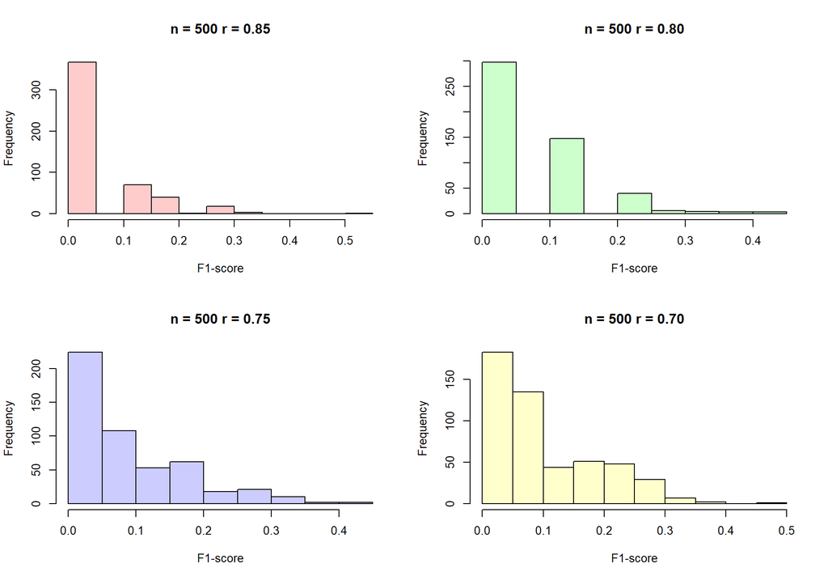

Parece que bajar el ratio mejora los resultados por tanto, he decidido volver a ejecutar el repeated hold out pero con 0.7 y no con 0.8. Los resultados son prácticamente idénticos, a veces añadiendo la variable RPro y otras no (he hecho varias ejecuciones para ver qué ocurría), al no afectar en las métricas incluir RPro, siempre que podamos simplificar el modelo lo haremos.

No podemos seguir bajando el ratio porque la función glm ya nos advierte de que está habiendo sobreajuste del modelo. A modo de curiosidad quiero mostrar lo que ocurre cuando bajamos mucho el porcentaje de entrenamiento.

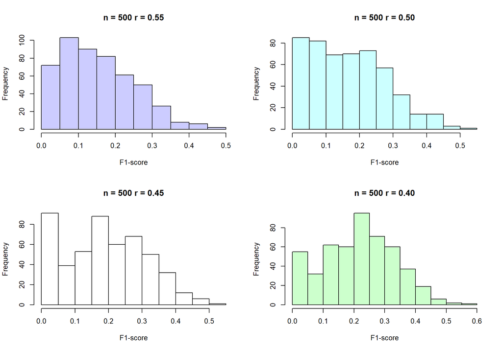

Parece que a menos datos de entrenamiento mejor, pero también nos arriesgamos a que el modelo no tenga capacidad predictiva.

## K-fold Cross Validation

Al realizar la implementación de la validación cruzada he podido eliminar menos datos.

```r
k.cross.validation <- function(datos, formula, k) {
    acc_train_test = 0
    f1score_train_test = 0
    levels(datos$REst)[levels(datos$REst) == "I"] <- NA
    levels(datos$RPro)[levels(datos$RPro) == "I"] <- NA
    levels(datos$Estadio)[levels(datos$Estadio) == "T0"] <- NA

    #levels(datos$Estadio)[levels(datos$Estadio) == "T1"] <- NA
    #levels(datos$Grado)[levels(datos$Grado) == "1"] <- NA
    folded.data <- createFolds(datos$PCR, k)
    for (i in 1:length(folded.data)) {
        training.set <- data.frame(datos[-unlist(folded.data[][i]),])
        test.set <- data.frame(datos[unlist(folded.data[][i]),])
        results = get.results(training.set, test.set, formula)
        acc_train_test = acc_train_test + results[1]
        f1score_train_test = f1score_train_test + results[4]
    }
    acc_train_test = acc_train_test / k
    f1score_train_test = f1score_train_test / k

    return (c(acc_train_test, f1score_train_test))
}
```

```r
test.all.combinations.cross <- function(datos, k) {
  combinations <- unlist(lapply(1:ncol(datos2[,-c(0,8)]), function(i) combn(colnames(datos2[,-c(0,8)]), i, simplify = FALSE)), recursive=FALSE)
  acc = 0
  best_f1score = 0
  best_model = combinations[1]

  # Vamos a ahorrarnos unas cuantas iteraciones si obviamos las primeras combinaciones que sabemos no van a ser las mejores.
  for (i in 28:length(combinations)) {
    str = paste(unlist(combinations[i]), collapse="+")
    str = paste("PCR ~", str)

    results = k.cross.validation(datos, str, k)

    if (results[2] > best_f1score) {
      acc = results[1]
      best_f1score = results[2]
      best_model = combinations[i]
    }
  }
  print(acc)
  print(best_f1score)
  print(best_model)
}
```

Realizando distintas ejecuciones obtenemos como mejor modelo al mismo que con repeated hold out.

Al igual que antes, hay que tener en cuenta que cuanto menos dividamos el dataset más fácil es perder la capacidad predictiva de nuestro modelo.

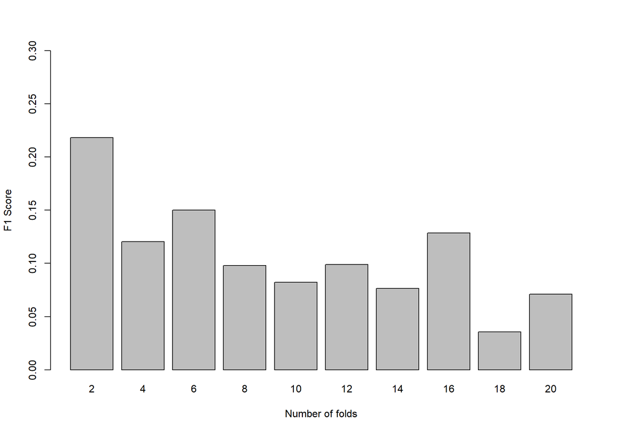

## Resultados

Si comparamos la media del F1-score de repeated hold out (r = 0.7) y la de validación cruzada apenas hay diferencia. Una vez llegados a lo que parece el modelo que mejor se ajusta a nuestro propósito, podemos utilizar todo el conjunto de datos para entrenamiento y obtener todas sus métricas. Tener en cuenta que estas métricas no hacen justicia a la capacidad predictiva del modelo, la sensibilidad va a ser muy pequeña ya que al usar todos los datos como entrenamiento nos vamos a ver en la misma situación que al principio del proyecto, pero en este caso no nos importa porque la forma en la que hemos llegado a este modelo ha intentado evitar este problema.

[output not shown]

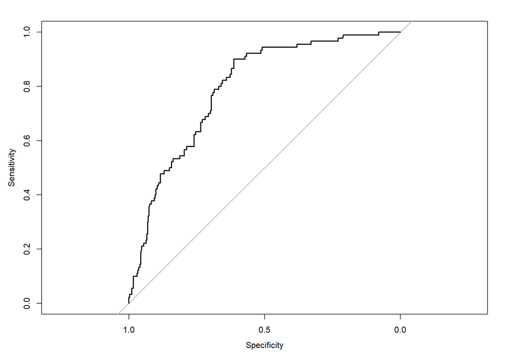

## Conclusiones

A lo largo de este trabajo hemos ido viendo distintas formas de hallar un modelo intentando evitar los efectos del sobreajuste. Finalmente hemos obtenido unos resultados de precisión y AUC aceptables, pero que a mi parecer, observando la matriz de confusión, siguen sin ser suficientemente buenos. Contamos con pocos datos, y además en algunas circunstancias tenemos que eliminar datos para evitar errores en la ejecución de los algoritmos, por tanto, sería sensato esperar a tener un dataset mayor, o buscar una manera de minimizar esa pérdida de información antes de lanzar este predictor al mercado.

También hay que tener en cuenta que en este proyecto ejecutar varias veces la misma función puede aportar resultados distintos, este problema nos sugiere buscar una forma más consistente de analizar los datos. Es por eso que veo los resultados obtenidos como aproximaciones que pueden ayudarme a sacar conclusiones, pero nunca para ser usados como único criterio a la hora de escoger el mejor modelo.

En el análisis bivariante vimos que las variables relacionadas con *PCR* eran *REst*, *RPro*, *Grado* y *Fenotipo*, nos parecía sospechoso que *NodAfec* no estuviese relacionada. Finalmente todos los modelos obtenidos en esta práctica sí han incluido esta variable, y algunos han omitido REst o RPro. La variable *Estadio* no estaba relacionada en principio con *PCR* y sin embargo casi todos los modelos la han incluido. Por algún motivo la variable *Edad* mejora el modelo pese a haber visto que tampoco tenía relación con *PCR*.

El modelo escogido finalmente ha sido *Edad + REst + Estadio + NodAfec + Grado + Fenotipo*, lo que quiere decir que hemos eliminado las variables *Muestra*, *RPro* y *Her2*. Como hemos comentado, necesitaríamos datos nuevos para poder obtener unas métricas más reales sobre la capacidad predictiva del modelo.

Consideraciones para el futuro: tener una parte de datos de validación, vamos a sobreestimar los resultados de otra forma. Buscar el mejor modelo en función de validación y no de test, y luego comprobar la capacidad predictiva del modelo con la parte de test. No lo hemos hecho para evitar complejizar demasiado el problema.